# Introduction

**Aim:**  
The aim of this project is to apply classification techniques to predict novel transcription factor target genes, focusing on Sox2 and Nanog during embryonic stem cell (ESC) differentiation.

**Background:**  
Transcriptional regulation is a fundamental process in all living organisms, driven by transcription factors that control mRNA expression. These transcriptional networks are crucial in development, lineage specification, and cell fate decisions during early embryonic development ([Theunissen and Jaenisch, 2017](https://doi.org/10.1038/nrm.2017.15)). Recent advances in omics technologies allow for the profiling of genome-wide transcriptional and epigenetic events, providing a deeper understanding of these networks.

In this project, we utilize high-temporal-resolution multi-omics data of ESC differentiation ([Yang et al., 2019](https://doi.org/10.1016/j.cell.2019.02.035)) to predict novel substrates of Sox2 and Nanog—two key transcription factors involved in maintaining pluripotency and guiding cell differentiation.

We will develop and validate a classification model to predict novel transcription factor target genes, focusing on Sox2 and Nanog, using the provided multi-omics datasets.

# Data Preparation

## Load Required Libraries and Data

We start by loading the necessary R packages and the dataset `Final_Project_ESC.RData`, which contains the transcriptome, proteome, and epigenome data, along with a subset of known Sox2/Nanog target genes.

```r
# Load necessary packages and data
load("Final_Project_ESC.RData", verbose = TRUE)
```

```
## Loading objects:
##   Transcriptome
##   Proteome
##   H3K4me3
##   H3K27me3
##   PolII
##   H3K4me1
##   H3K27ac
##   H3K9me2
##   cMyc_target_genes
##   cMyc_target_genes_subset
##   OSN_target_genes
##   OSN_target_genes_subset
```

```r
suppressPackageStartupMessages({
    library(e1071)
    library(ggplot2)
    library(ROCR)
    library(calibrate)
    library(dplyr)
    library(tibble)
    library(reshape2)
    library(kernlab)
    library(caret)
    library(randomForest)
    library(adabag)
    library(gbm)
    library(xgboost)
    library(pROC)
    library(doParallel)
})
```

head(Transcriptome) dim(Transcriptome) colnames(Transcriptome)

# PCA analysis on the correlation matrix of the transcriptome data

cor.mat <- cor(Transcriptome) pca.mat <- prcomp(cor.mat)

# Plot the PCA

grp <- rownames(pca.mat$x) grp.col <- rainbow(nrow(pca.mat$x)) names(grp.col) <- rownames(pca.mat$x)

# Generate PCA plot

plot(pca.mat$x[,1], pca.mat$x[,2], col=grp.col[grp], pch=19, cex=2, xlab=paste0(“PC1 (”, round(summary(pca.mat)$importance[2,1]*100,1), "% variance)"), ylab=paste0("PC2 (", round(summary(pca.mat)$importance[2,2]*100,1), “% variance)”))

# Add sample labels to the plot

calibrate::textxy(pca.mat$x[,1], pca.mat$x[,2], labs=grp, cex=0.5)

#Proteome cor.proteome <- cor(Proteome) pca.proteome <- prcomp(cor.proteome) summary(pca.proteome)$importance

# Using the previous correlation matrix and PCA results

cor.proteome <- cor(Proteome) pca.proteome <- prcomp(cor.proteome)

# Get group labels and colors

grp <- rownames(pca.proteome$x) # Set groups according to your data grp.col <- rainbow(nrow(pca.proteome$x)) names(grp.col) <- rownames(pca.proteome$x)

# Plot the PCA

plot(pca.proteome$x[,1], pca.proteome$x[,2], col=grp.col[grp], pch=19, cex=2, xlab=paste0(“PC1 (”, round(summary(pca.proteome)$importance[2,1]*100,1), "% variance)"), ylab=paste0("PC2 (", round(summary(pca.proteome)$importance[2,2]*100,1), “% variance)”))

#General PCA and Plotting Code for Epigenome Data #h3k4me3 # PCA analysis on the correlation matrix of the H3K4me3 data cor.h3k4me3 <- cor(H3K4me3) pca.h3k4me3 <- prcomp(cor.h3k4me3)

# Get group labels and colors

grp <- rownames(pca.h3k4me3$x) grp.col <- rainbow(nrow(pca.h3k4me3$x)) names(grp.col) <- rownames(pca.h3k4me3$x)

# Generate PCA plot for H3K4me3

plot(pca.h3k4me3$x[,1], pca.h3k4me3$x[,2], col=grp.col[grp], pch=19, cex=2, xlab=paste0(“PC1 (”, round(summary(pca.h3k4me3)$importance[2,1]*100,1), "% variance)"), ylab=paste0("PC2 (", round(summary(pca.h3k4me3)$importance[2,2]*100,1), “% variance)”))

# Add sample labels to the plot

calibrate::textxy(pca.h3k4me3$x[,1], pca.h3k4me3$x[,2], labs=grp, cex=0.5)

#H3K27me3 # PCA analysis for H3K27me3 data cor.h3k27me3 <- cor(H3K27me3) pca.h3k27me3 <- prcomp(cor.h3k27me3)

# Update group labels and colors for H3K27ac

grp.h3k27ac <- rownames(pca.h3k27ac$x) grp.col.h3k27ac <- rainbow(nrow(pca.h3k27ac$x)) names(grp.col.h3k27ac) <- rownames(pca.h3k27ac$x)

# Generate PCA plot for H3K27ac

plot(pca.h3k27ac$x[,1], pca.h3k27ac$x[,2], col=grp.col.h3k27ac[grp.h3k27ac], pch=19, cex=2, xlab=paste0(“PC1 (”, round(summary(pca.h3k27ac)$importance[2,1]*100,1), "% variance)"), ylab=paste0("PC2 (", round(summary(pca.h3k27ac)$importance[2,2]*100,1), “% variance)”))

# Correctly label the samples for H3K27ac

calibrate::textxy(pca.h3k27ac$x[,1], pca.h3k27ac$x[,2], labs=grp.h3k27ac, cex=0.5)

#H3K4me1 # PCA analysis for H3K4me1 data cor.h3k4me1 <- cor(H3K4me1) pca.h3k4me1 <- prcomp(cor.h3k4me1)

# Define the group labels and colors specifically for H3K4me1 data

grp.h3k4me1 <- rownames(pca.h3k4me1$x) grp.col.h3k4me1 <- rainbow(nrow(pca.h3k4me1$x)) names(grp.col.h3k4me1) <- rownames(pca.h3k4me1$x)

# Generate PCA plot for H3K4me1

plot(pca.h3k4me1$x[,1], pca.h3k4me1$x[,2], col=grp.col.h3k4me1[grp.h3k4me1], pch=19, cex=2, xlab=paste0(“PC1 (”, round(summary(pca.h3k4me1)$importance[2,1]*100,1), "% variance)"), ylab=paste0("PC2 (", round(summary(pca.h3k4me1)$importance[2,2]*100,1), “% variance)”))

# Correctly label the samples for H3K4me1

calibrate::textxy(pca.h3k4me1$x[,1], pca.h3k4me1$x[,2], labs=grp.h3k4me1, cex=0.5)

#H3K9me2 # PCA analysis for H3K9me2 data cor.h3k9me2 <- cor(H3K9me2) pca.h3k9me2 <- prcomp(cor.h3k9me2)

# Define the group labels and colors specifically for H3K9me2 data

grp.h3k9me2 <- rownames(pca.h3k9me2$x) grp.col.h3k9me2 <- rainbow(nrow(pca.h3k9me2$x)) names(grp.col.h3k9me2) <- rownames(pca.h3k9me2$x)

# Generate PCA plot for H3K9me2

plot(pca.h3k9me2$x[,1], pca.h3k9me2$x[,2], col=grp.col.h3k9me2[grp.h3k9me2], pch=19, cex=2, xlab=paste0(“PC1 (”, round(summary(pca.h3k9me2)$importance[2,1]*100,1), "% variance)"), ylab=paste0("PC2 (", round(summary(pca.h3k9me2)$importance[2,2]*100,1), “% variance)”))

# Correctly label the samples for H3K9me2

calibrate::textxy(pca.h3k9me2$x[,1], pca.h3k9me2$x[,2], labs=grp.h3k9me2, cex=0.5)

#PolII # PCA analysis for PolII data cor.polii <- cor(PolII) pca.polii <- prcomp(cor.polii)

# Define the group labels and colors specifically for PolII data

grp.polii <- rownames(pca.polii$x) grp.col.polii <- rainbow(nrow(pca.polii$x)) names(grp.col.polii) <- rownames(pca.polii$x)

# Generate PCA plot for PolII

plot(pca.polii$x[,1], pca.polii$x[,2], col=grp.col.polii[grp.polii], pch=19, cex=2, xlab=paste0(“PC1 (”, round(summary(pca.polii)$importance[2,1]*100,1), "% variance)"), ylab=paste0("PC2 (", round(summary(pca.polii)$importance[2,2]*100,1), “% variance)”))

# Correctly label the samples for PolII

calibrate::textxy(pca.polii$x[,1], pca.polii$x[,2], labs=grp.polii, cex=0.5)

## Filter and Combine Datasets

To ensure consistency across datasets, we filter each dataset to include only the common genes present in all omics layers. We then combine these filtered datasets into a single data frame for further analysis.

```r
# Ensure all data has the same set of genes
genes <- intersect(rownames(Transcriptome), rownames(Proteome))
genes <- intersect(genes, rownames(H3K4me3))
genes <- intersect(genes, rownames(H3K27me3))
genes <- intersect(genes, rownames(H3K27ac))
genes <- intersect(genes, rownames(H3K4me1))
genes <- intersect(genes, rownames(H3K9me2))
genes <- intersect(genes, rownames(PolII))
```

```r
# Filter each dataset for the common genes
Transcriptome_filter <- Transcriptome[genes, ]
Proteome_filter <- Proteome[genes, ]
H3K4me3_filter <- H3K4me3[genes, ]
H3K27me3_filter <- H3K27me3[genes, ]
H3K27ac_filter <- H3K27ac[genes, ]
H3K4me1_filter <- H3K4me1[genes, ]
H3K9me2_filter <- H3K9me2[genes, ]
PolII_filter <- PolII[genes, ]
```

```r
# Rename columns to avoid conflicts
colnames(Transcriptome_filter) <- paste("T_", colnames(Transcriptome_filter), sep = "")
colnames(Proteome_filter) <- paste("P_", colnames(Proteome_filter), sep = "")
colnames(H3K4me3_filter) <- paste("H3K4me3_", colnames(H3K4me3_filter), sep = "")
colnames(H3K27me3_filter) <- paste("H3K27me3_", colnames(H3K27me3_filter), sep = "")
colnames(H3K27ac_filter) <- paste("H3K27ac_", colnames(H3K27ac_filter), sep = "")
colnames(H3K4me1_filter) <- paste("H3K4me1_", colnames(H3K4me1_filter), sep = "")
colnames(H3K9me2_filter) <- paste("H3K9me2_", colnames(H3K9me2_filter), sep = "")
colnames(PolII_filter) <- paste("PolII_", colnames(PolII_filter), sep = "")

# Combine the datasets
combined_data <- cbind(
  Transcriptome_filter,
  Proteome_filter,
  H3K4me3_filter,
  H3K27me3_filter,
  H3K27ac_filter,
  H3K4me1_filter,
  H3K9me2_filter,
  PolII_filter
)

# Add the labels
label <- ifelse(genes %in% OSN_target_genes_subset, "OSN", "Other")
combined_data <- data.frame(combined_data)
combined_data$label <- factor(label)
```

```r
# Check the initial label distribution
print(table(combined_data$label))
```

```
##
##   OSN Other
##    95  8085
```

## Data Splitting and Balancing

The dataset is split into training (90%) and testing (10%) sets. The label column is reassigned to the test set to ensure that it is included correctly.

```r
# Split the dataset into training (90%) and testing (10%) sets
set.seed(123)
train_index <- createDataPartition(combined_data$label, p = 0.9, list = FALSE)

train_data <- combined_data[train_index, ]
test_data <- combined_data[-train_index, ]

# Reassign the label column to test_data
test_data$label <- combined_data[-train_index, "label"]

# Check the distribution of labels in the training and test sets
print("Training set label distribution:")
```

```
## [1] "Training set label distribution:"
```

```r
print(table(train_data$label))
```

```
##
##   OSN Other
##    86  7277
```

```r
print("Test set label distribution:")
```

```
## [1] "Test set label distribution:"
```

```r
print(table(test_data$label))
```

```
##
##   OSN Other
##     9   808
```

## Balancing the Training Data

Since the dataset is imbalanced, downsampling is used to create a balanced training dataset. This ensures that both classes (OSN and Other) are equally represented, improving the robustness of the classification model.

```r
# Balance the training data using downsampling
set.seed(123)
downsampled_train_data <- downSample(x = train_data[, -ncol(train_data)],
                                     y = train_data$label,
                                     yname = "label")

# Check the balanced label distribution
print("Balanced training set label distribution:")
```

```
## [1] "Balanced training set label distribution:"
```

```r
print(table(downsampled_train_data$label))
```

```
##
##   OSN Other
##    86    86
```

```r
# Final check of training dataset dimensions
print(dim(downsampled_train_data))
```

```
## [1] 172  64
```

# Model Training

Train SVM and Random Forest Models We train two machine learning models, SVM and Random Forest, using the balanced training dataset.

```r
# Set a consistent seed
set.seed(123)
```

```r
# Train an SVM model on the downsampled training data with radial basis function kernel
svm_model <- svm(label ~ ., data = downsampled_train_data, kernel = "radial", probability = TRUE)

# Train a Random Forest model on the downsampled training data
set.seed(123)
rf_model <- randomForest(label ~ ., data = downsampled_train_data, ntree = 1000)
```

## Bagging w/ Bagged Trees

```r
bagged_trees <- train(
  label ~ .,
  data = downsampled_train_data,
  method = "treebag",
  trControl = trainControl(method = "cv", number = 5),
  tuneLength = 5
)
print(bagged_trees)
```

```
## Bagged CART
##
## 172 samples
##  63 predictor
##   2 classes: 'OSN', 'Other'
##
## No pre-processing
## Resampling: Cross-Validated (5 fold)
## Summary of sample sizes: 137, 138, 138, 137, 138
## Resampling results:
##
##   Accuracy   Kappa
##   0.7447059  0.4888148
```

## GBM w/ Hyperparam Tuning and xgboost (using parallel processing)

```r
tune_grid_xgb <- expand.grid(
  nrounds = c(100, 200),
  max_depth = c(3, 6),
  eta = c(0.1, 0.3),
  gamma = c(0, 0.1),
  colsample_bytree = c(0.5, 1),
  min_child_weight = c(1, 10),
  subsample = c(0.5, 1)
)

cl <- makeCluster(detectCores())
registerDoParallel(cl)

train_control <- trainControl(
  method = "cv",
  number = 3,
  savePredictions = "final",
  verboseIter = TRUE,
  allowParallel = TRUE
)

xgb_model_tuned <- train(
  label ~ .,
  data = downsampled_train_data,
  method = "xgbTree",
  trControl = train_control,
  tuneGrid = tune_grid_xgb,
  metric = "Accuracy"  # Performance Metric
)
```

```
## Fitting nrounds = 100, max_depth = 3, eta = 0.1, gamma = 0.1, colsample_bytree = 1, min_child_weight = 1, subsample = 0.5 on full training set
```

```r
print(xgb_model_tuned)
```

```
## eXtreme Gradient Boosting
##
## 172 samples
##  63 predictor
##   2 classes: 'OSN', 'Other'
##
## No pre-processing
## Resampling: Cross-Validated (3 fold)
## Summary of sample sizes: 114, 116, 114
## Resampling results across tuning parameters:
##
##   eta  max_depth  gamma  colsample_bytree  min_child_weight  subsample  nrounds
##   0.1  3          0.0    0.5                1                0.5        100
##   0.1  3          0.0    0.5                1                0.5        200
##   0.1  3          0.0    0.5                1                1.0        100
##   0.1  3          0.0    0.5                1                1.0        200
##   0.1  3          0.0    0.5               10                0.5        100
##   0.1  3          0.0    0.5               10                0.5        200
##   0.1  3          0.0    0.5               10                1.0        100
##   0.1  3          0.0    0.5               10                1.0        200
##   0.1  3          0.0    1.0                1                0.5        100
##   0.1  3          0.0    1.0                1                0.5        200
##   0.1  3          0.0    1.0                1                1.0        100
##   0.1  3          0.0    1.0                1                1.0        200
##   0.1  3          0.0    1.0               10                0.5        100
##   0.1  3          0.0    1.0               10                0.5        200
##   0.1  3          0.0    1.0               10                1.0        100
##   0.1  3          0.0    1.0               10                1.0        200
##   0.1  3          0.1    0.5                1                0.5        100
##   0.1  3          0.1    0.5                1                0.5        200
##   0.1  3          0.1    0.5                1                1.0        100
##   0.1  3          0.1    0.5                1                1.0        200
##   0.1  3          0.1    0.5               10                0.5        100
##   0.1  3          0.1    0.5               10                0.5        200
##   0.1  3          0.1    0.5               10                1.0        100
##   0.1  3          0.1    0.5               10                1.0        200
##   0.1  3          0.1    1.0                1                0.5        100
##   0.1  3          0.1    1.0                1                0.5        200
##   0.1  3          0.1    1.0                1                1.0        100
##   0.1  3          0.1    1.0                1                1.0        200
```

[output cut: 219 more lines]

```
##   0.6683087  0.3366174
##   0.6683087  0.3366174
##   0.7442529  0.4885057
##   0.7383005  0.4766010
##   0.7040230  0.4080460
##   0.7040230  0.4080460
##   0.5000000  0.0000000
##   0.5000000  0.0000000
##   0.6800082  0.3600164
##   0.6800082  0.3600164
##
## Accuracy was used to select the optimal model using the largest value.
## The final values used for the model were nrounds = 100, max_depth = 3, eta
##  = 0.1, gamma = 0.1, colsample_bytree = 1, min_child_weight = 1 and subsample
##  = 0.5.
```

```r
# Printing the best model's details
print(xgb_model_tuned$bestTune)
```

```
##    nrounds max_depth eta gamma colsample_bytree min_child_weight subsample
## 25     100         3 0.1   0.1                1                1       0.5
```

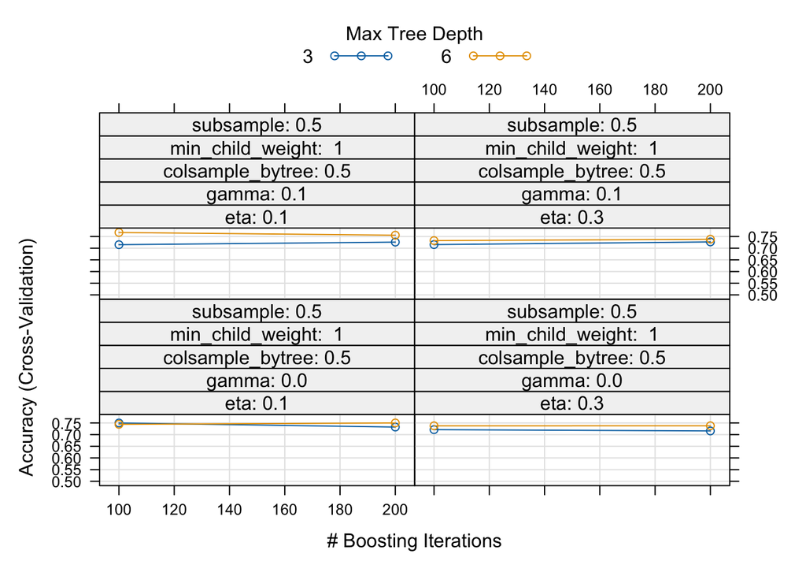

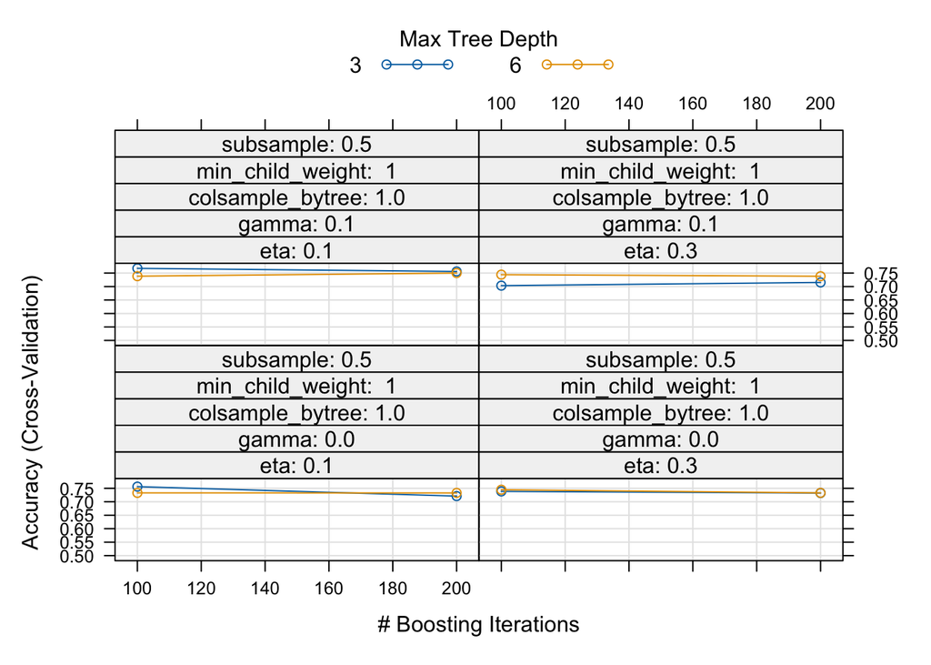

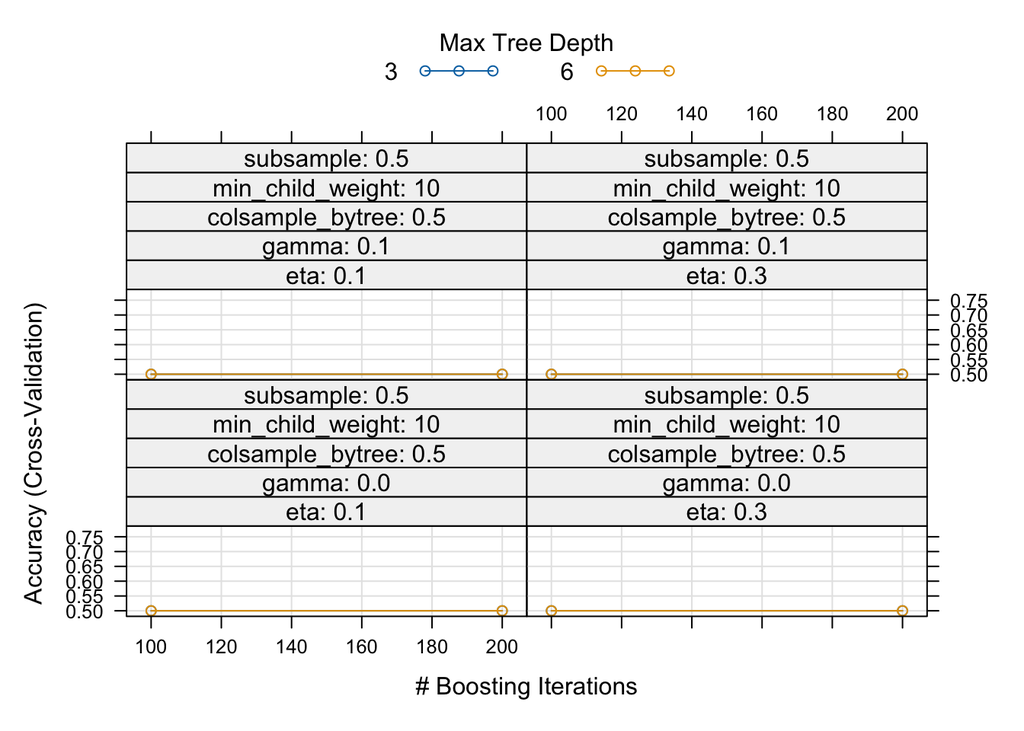

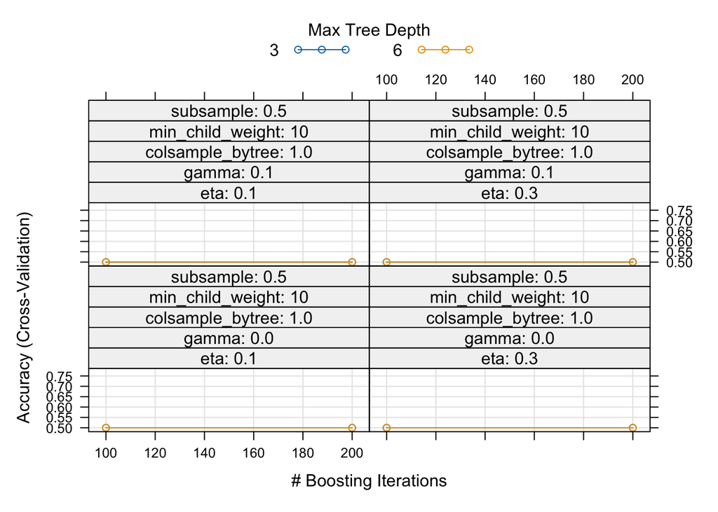

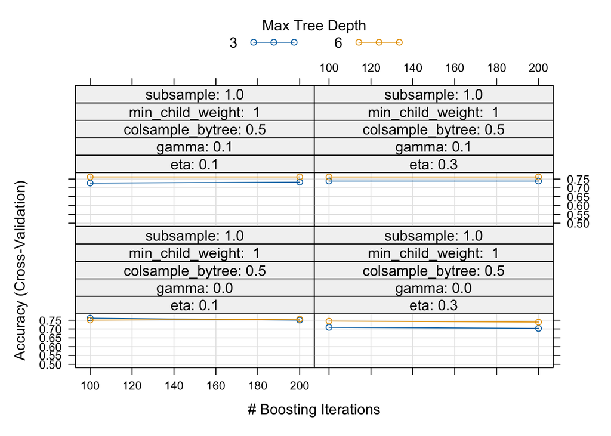

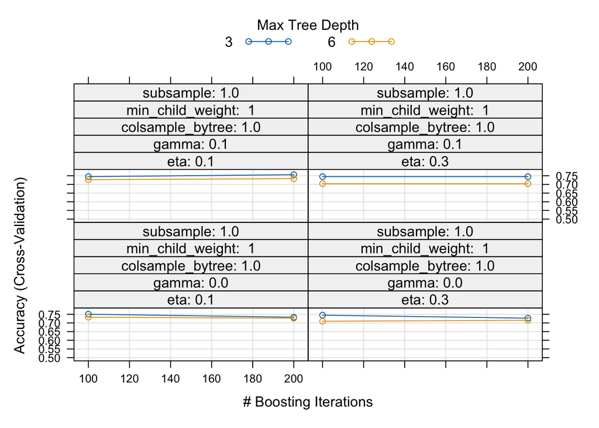

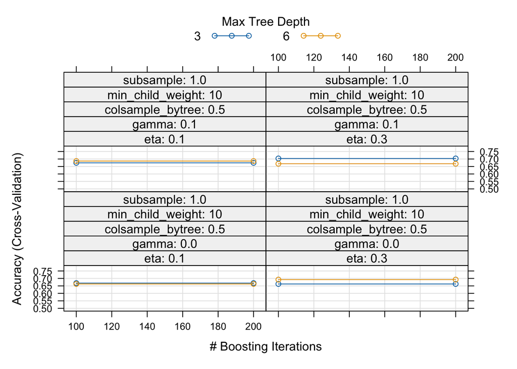

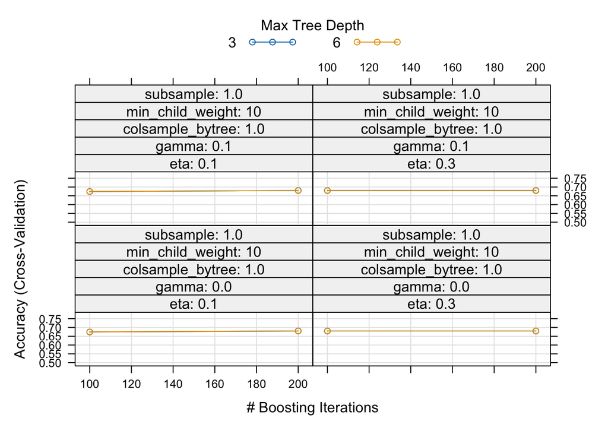

```r
# Plotting model performance
plot(xgb_model_tuned)
```

# Model Evaluation

Predictions and Confusion Matrix We use the trained models to make predictions on the test set and evaluate their performance using confusion matrices.

```r
# Ensure column names in the test set match the training data
colnames(test_data) <- colnames(downsampled_train_data)[1:(ncol(downsampled_train_data) - 1)]  # Exclude the label column

# Check if the label column is present and correctly populated
if ("label" %in% colnames(combined_data) && length(combined_data[-train_index, "label"]) == nrow(test_data)) {
    # Assign the label to test_data
    test_data$label <- combined_data[-train_index, "label"]
} else {
    stop("The label vector is empty or has a different length than expected. Check the data preparation steps.")
}

# Ensure the label is a factor with the correct levels
test_data$label <- factor(test_data$label, levels = c("OSN", "Other"))

# SVM Predictions on the test set
svm_test_pred <- predict(svm_model, newdata = test_data[, -ncol(test_data)], probability = TRUE)
svm_test_prob <- attr(svm_test_pred, "probabilities")[, "OSN"]

# Random Forest Predictions on the test set
rf_test_pred <- predict(rf_model, newdata = test_data[, -ncol(test_data)], type = "prob")[, "OSN"]

# SVM Confusion Matrix on the test set
svm_test_conf_matrix <- table(Predicted = ifelse(svm_test_prob > 0.5, "OSN", "Other"), Actual = test_data$label)
print("SVM Test Confusion Matrix:")
```

```
## [1] "SVM Test Confusion Matrix:"
```

```r
print(svm_test_conf_matrix)
```

```
##          Actual
## Predicted OSN Other
##     OSN     7   194
##     Other   2   614
```

```r
# Random Forest Confusion Matrix on the test set
rf_test_conf_matrix <- table(Predicted = ifelse(rf_test_pred > 0.5, "OSN", "Other"), Actual = test_data$label)
print("Random Forest Test Confusion Matrix:")
```

```
## [1] "Random Forest Test Confusion Matrix:"
```

```r
print(rf_test_conf_matrix)
```

```
##          Actual
## Predicted OSN Other
##     OSN     8   204
##     Other   1   604
```

## ROC Curve and AUC

To further assess model performance, we plot the ROC curves and calculate the AUC for both the SVM and Random Forest models.

```r
# Evaluate the models on the test set (AUC and ROC)
svm_test_roc <- roc(test_data$label, svm_test_prob)
```

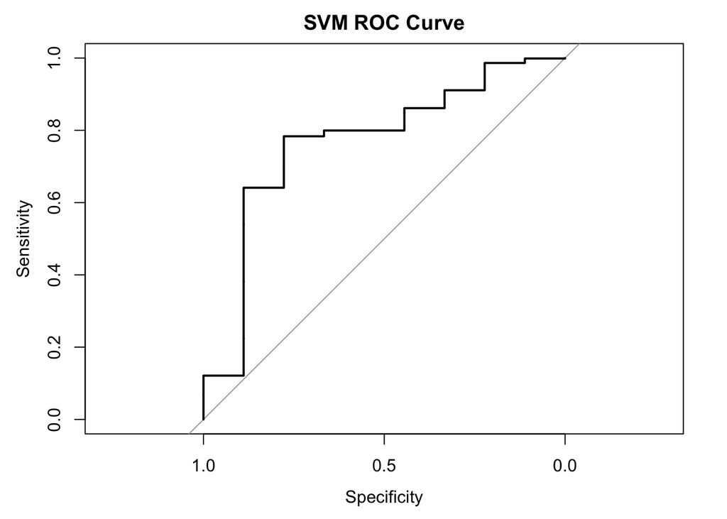

```r
plot(svm_test_roc, main = "SVM ROC Curve")
```

```r
print(paste("Final SVM Test AUC:", auc(svm_test_roc)))
```

```
## [1] "Final SVM Test AUC: 0.766914191419142"
```

```r
rf_test_roc <- roc(test_data$label, rf_test_pred)
```

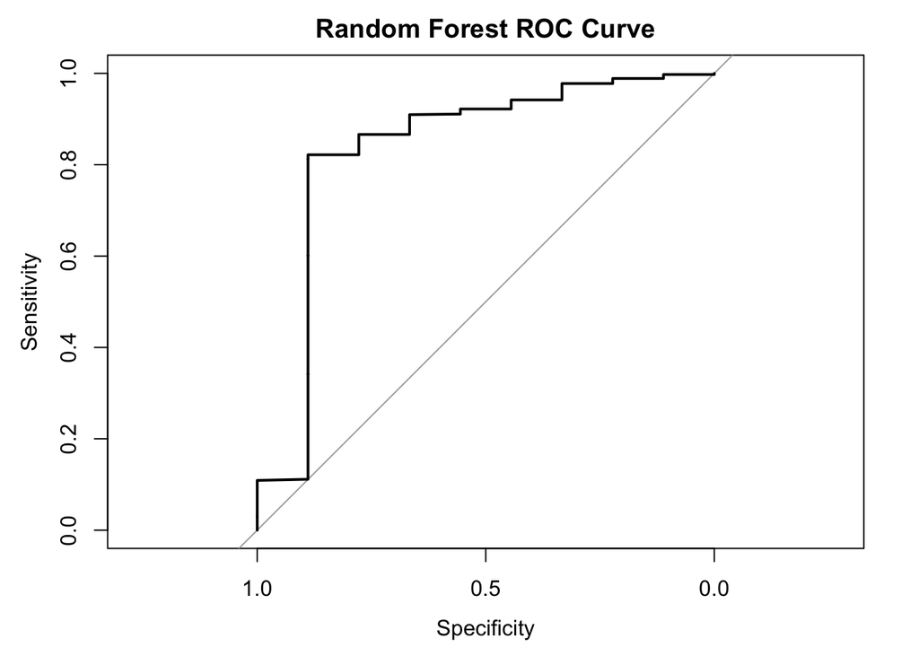

```r
plot(rf_test_roc, main = "Random Forest ROC Curve")
```

```r
print(paste("Final Random Forest Test AUC:", auc(rf_test_roc)))
```

```
## [1] "Final Random Forest Test AUC: 0.8373899889989"
```

# Future Directions:

**Model Improvement:**  
Further hyperparameter tuning using automated methods like grid search or random search could refine the model’s accuracy. Additionally, exploring ensemble methods that combine predictions from several models might yield better results.

**Data Expansion:**  
Incorporating additional omics layers, such as metabolomics or additional transcription factor binding profiles, could help to improve the model’s predictive power and generalisability.

**Integration with Clinical Data:**  
Linking omics profiles with clinical outcomes could also be explored to improve the translational impact of the research.